# EXAMPLE OF USE SYNTHETIC DATA GENERATION PACKAGE

```python
from IPython.display import HTML

HTML('''<script>
code_show=true;
function code_toggle() {
 if (code_show){
 $('div.input').hide();
 } else {
 $('div.input').show();
 }
 code_show = !code_show
}
$( document ).ready(code_toggle);
</script>
<form action="javascript:code_toggle()"><input type="submit" value="Click here to toggle on/off the raw code."></form>''')
```

```python
%load_ext rmagic
```

```python
from IPython.display import Latex
```

This case of use will be based on generating and comparing the predictive performance of students' results data generated according to different models. This library allows the generation of data using 7 different models that will be described in more detail later. So the point of this case of use will be to generate data using the provided functions and according to different models. After this, we will generate performance data using a specific underlying model and we will analyse the predictive performance of the other models. This will be clarified farther with particular examples. All the data used will be synthetic data, generated according to our needs and using the library's functions.

So, the first step is to load the library we are working with: Synthetic Data Generation.

```
library(SDG)
```

```python
%%R
library(SDG)
```

Once we have imported all the functionalities of the SDG package, the example of use starts by generating a matrix involving 10 students and 4 skills. Each element will represent the probability of a student to succeed an item that calls for the correspondent skill. This information is generated according to the Gaussian function.

The function used is skillsGen(), that generates data according to the standard distribution, as mentioned before. We will consider a mean of 0 and a standard deviation of 1. If we would like to introduce a noise while predicting the students' skills, we could modify the standard deviation of the Gaussian function by changing the 'deviation' parameter. The matrix generated here will be the skills matrix used along the whole document.

```
skills <- skillsGen(sts = 10,mean = 0, deviation = 1,rank = 4)
```

```python
%%R
skills <- skillsGen(sts = 10,mean = 0, deviation = 1,rank = 4)
```

The next step is to get a graph that, using a grid, represents the information in a more visual way. On the one hand, the red cells represent values closer to 0, corresponding to less probability of success for the correspondent student and the given item. On the other hand, the white cells represent values closer to 1. We expect a big variety of values due to the parameters used in the standard distribution. Before plotting it, we can see the generated skills matrix with its numerical values:

$$\\\hspace{1.5cm}Skills \\Students\left(\begin{matrix} 0.5331611 & 0.28072709 & 0.61022624 & 0.7196679 \\ 0.4706583 & 0.68450836 & 0.03774574 & 0.3675002\\ 0.9810095 & 0.24154372 & 0.81285467 & 0.9950425\\ 0.5228266 & 0.09036572 & 0.90412467 & 0.8735288\\ 0.7022250 & 0.28914964 & 0.98592405 & 0.4444356\\ 0.4610726 & 0.72349372 & 0.73188106 & 0.8285151\\ 0.7839393 & 0.83858406 & 0.21673091 & 0.2187936\\ 0.4074115 & 0.35472920 & 0.40375519 & 0.4707774\\ 0.9076050 & 0.93828625 & 0.53785757 & 0.7592005\\ 0.8377285 & 0.61375846 & 0.57157048 & 0.5134974\\ \end{matrix} \right)$$

The function used to plot the graph is oimage(), in which the user can display the matrix and label it depending on how the information is needed. In this particular case, we transpose the skills matrix so the information is displayed in a more understandable way. As an example, the second student's probability to succeed an item involving the skill 3 will decrease due to his 'level' in this skill (0.03774574), represented as a red cell in the graph.

```
oimage(t(skills),xlab='Student', ylab='Skill')
```

```python
%%R
oimage(t(skills),xlab='Student', ylab='Skill')
```

[output not shown]

Once we have the skills matrix, we need the information about the set of items that the students are going to answer. So we generate this group of items using a Q-Matrix involving 4 skills, according to the number of skills defined while generating the skills matrix. In order to get this kind of data, the QgenInc() function is used, in which the 'maxSkillsPerItem' parameter will define the number of items generated. We set it to 4, which means that we will have a number of items corresponding to all the combinations, involving maximum 4 skills. Starting by items that call for one skill, then two skills and so on. The last item will require all the 4 skills.

```
    qMatrix <- QgenInc(num.skills = 4,maxSkillsPerItem = 4)
```

```python
%%R
qMatrix <- QgenInc(num.skills = 4,maxSkillsPerItem = 4)
```

As we can see in the following matrix, formed by binomial values, the success of an item will depend on the skill or skills involved in that item. For example, for the first item, represented by the first column, we find a 1 in the first row, which means that the skill one is required to succeed the item 1. So the student's success or failure on this item will depend on his ability in the given skill, value coming from the skills matrix. The same reasoning would apply for the items involving more than one skill.

The generated Q-Matrix is the next:

$$\\\hspace{1.5cm}Items \\Skills\left(\begin{matrix} 1 & 0 & 0 & 0 & 1 & 1 & 1 & 0 & 0 & 0 & 1 & 1 & 1 & 0 & 1\\ 0 & 1 & 0 & 0 & 1 & 0 & 0 & 1 & 1 & 0 & 1 & 1 & 0 & 1 & 1\\ 0 & 0 & 1 & 0 & 0 & 1 & 0 & 1 & 0 & 1 & 1 & 0 & 1 & 1 & 1\\ 0 & 0 & 0 & 1 & 0 & 0 & 1 & 0 & 1 & 1 & 0 & 1 & 1 & 1 & 1\\ \end{matrix} \right)$$

We get the grid corresponding to the Q-Matrix generated. Since it's a {0,1} values matrix, red cells stand for 0's and white cells for 1's.

```
oimage(qMatrix,xlab='Item', ylab='Skill')
```

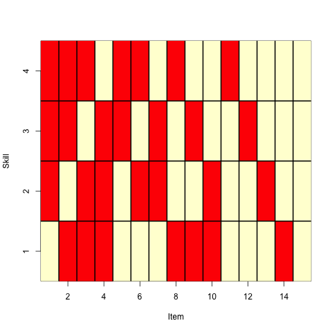

```python
%%R
oimage(qMatrix,xlab='Item', ylab='Skill')
```

As we can see, the first 4 items only involve 1 skill per item. From item 5 to 10, 2 skills are involved and so on. At last, we get a set of 15 items with different difficulties or number of skills involved.